# Explore Red Wine Data

Eatidal

========================================================

# Introduction

```
## [1] 1599   13
```

The datasets to be explores describing a Wine Quality Red. We have 13 variables and 1,599 red wines based on their chemical properties, the quality score between 0 (very bad) and 10 (very excellent).

# Univariate Plots Section

```
## 'data.frame':    1599 obs. of  13 variables:
##  $ X                   : int  1 2 3 4 5 6 7 8 9 10 ...
##  $ fixed.acidity       : num  7.4 7.8 7.8 11.2 7.4 7.4 7.9 7.3 7.8 7.5 ...
##  $ volatile.acidity    : num  0.7 0.88 0.76 0.28 0.7 0.66 0.6 0.65 0.58 0.5 ...
##  $ citric.acid         : num  0 0 0.04 0.56 0 0 0.06 0 0.02 0.36 ...
##  $ residual.sugar      : num  1.9 2.6 2.3 1.9 1.9 1.8 1.6 1.2 2 6.1 ...
##  $ chlorides           : num  0.076 0.098 0.092 0.075 0.076 0.075 0.069 0.065 0.073 0.071 ...
##  $ free.sulfur.dioxide : num  11 25 15 17 11 13 15 15 9 17 ...
##  $ total.sulfur.dioxide: num  34 67 54 60 34 40 59 21 18 102 ...
##  $ density             : num  0.998 0.997 0.997 0.998 0.998 ...
##  $ pH                  : num  3.51 3.2 3.26 3.16 3.51 3.51 3.3 3.39 3.36 3.35 ...
##  $ sulphates           : num  0.56 0.68 0.65 0.58 0.56 0.56 0.46 0.47 0.57 0.8 ...
##  $ alcohol             : num  9.4 9.8 9.8 9.8 9.4 9.4 9.4 10 9.5 10.5 ...
##  $ quality             : int  5 5 5 6 5 5 5 7 7 5 ...
```

```
##        X          fixed.acidity   volatile.acidity  citric.acid
##  Min.   :   1.0   Min.   : 4.60   Min.   :0.1200   Min.   :0.000
##  1st Qu.: 400.5   1st Qu.: 7.10   1st Qu.:0.3900   1st Qu.:0.090
##  Median : 800.0   Median : 7.90   Median :0.5200   Median :0.260
##  Mean   : 800.0   Mean   : 8.32   Mean   :0.5278   Mean   :0.271
##  3rd Qu.:1199.5   3rd Qu.: 9.20   3rd Qu.:0.6400   3rd Qu.:0.420
##  Max.   :1599.0   Max.   :15.90   Max.   :1.5800   Max.   :1.000
##  residual.sugar     chlorides       free.sulfur.dioxide
##  Min.   : 0.900   Min.   :0.01200   Min.   : 1.00
##  1st Qu.: 1.900   1st Qu.:0.07000   1st Qu.: 7.00
##  Median : 2.200   Median :0.07900   Median :14.00
##  Mean   : 2.539   Mean   :0.08747   Mean   :15.87
##  3rd Qu.: 2.600   3rd Qu.:0.09000   3rd Qu.:21.00
##  Max.   :15.500   Max.   :0.61100   Max.   :72.00
##  total.sulfur.dioxide    density             pH          sulphates
##  Min.   :  6.00       Min.   :0.9901   Min.   :2.740   Min.   :0.3300
##  1st Qu.: 22.00       1st Qu.:0.9956   1st Qu.:3.210   1st Qu.:0.5500
##  Median : 38.00       Median :0.9968   Median :3.310   Median :0.6200
##  Mean   : 46.47       Mean   :0.9967   Mean   :3.311   Mean   :0.6581
##  3rd Qu.: 62.00       3rd Qu.:0.9978   3rd Qu.:3.400   3rd Qu.:0.7300
##  Max.   :289.00       Max.   :1.0037   Max.   :4.010   Max.   :2.0000
##     alcohol         quality
##  Min.   : 8.40   Min.   :3.000
##  1st Qu.: 9.50   1st Qu.:5.000
##  Median :10.20   Median :6.000
##  Mean   :10.42   Mean   :5.636
##  3rd Qu.:11.10   3rd Qu.:6.000
##  Max.   :14.90   Max.   :8.000
```

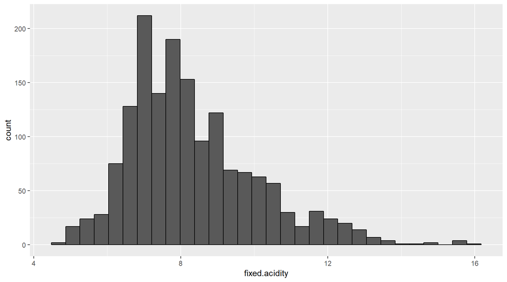

We can see the fixed acidity graph is right skewed. The wines have an acidity range between 4 and 16, most values range between 6 and 10.

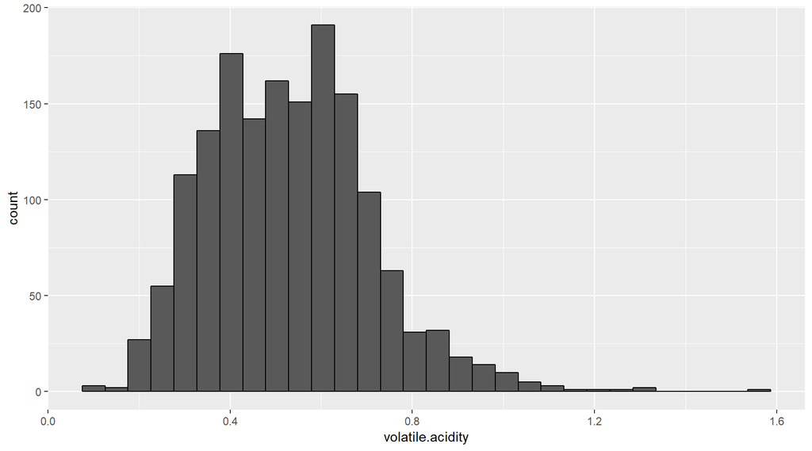

We can see the volatile acidity graph is bimodal right skewed. The wines have an acidity range between 0.1 and 1.6, most values range between 0.3 and 0.7.

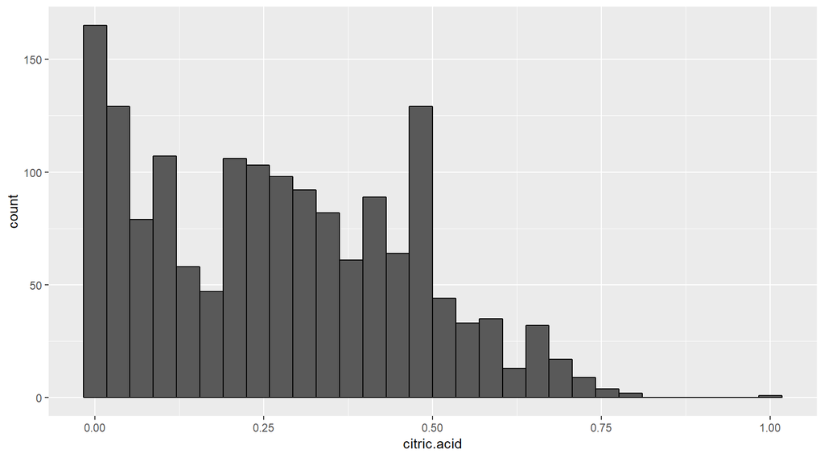

```
##
## FALSE  TRUE
##  1467   132
```

We have some of wines (132 wines) don’t contain the citric.acid. Citric acid values range between 0 and 1, most values below 0.7.

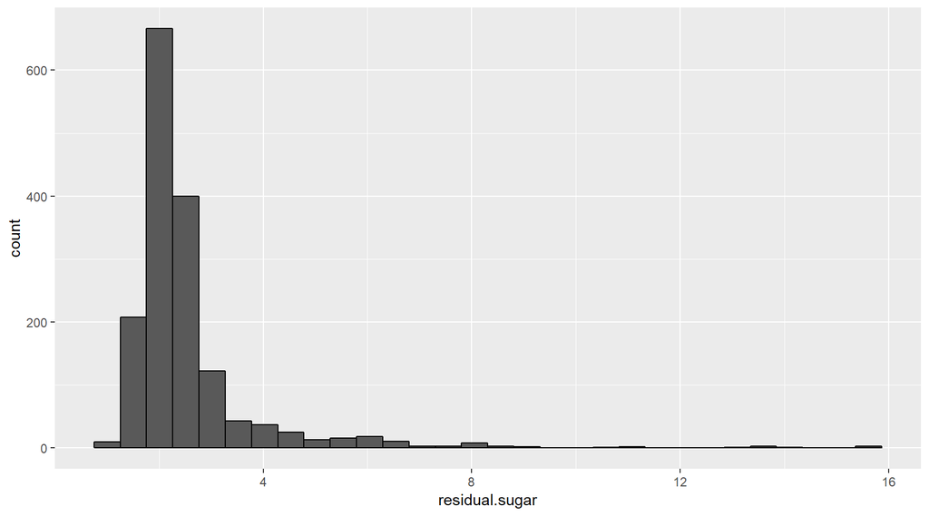

The distribution of residual sugar graph is right skewed and long tail in the right side.

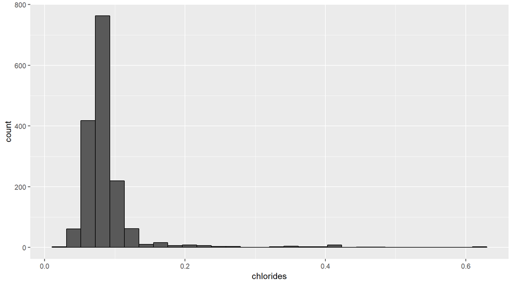

Chloricles is right skewed distribution. The chloricles have most values range between 0.05 to 0.1.

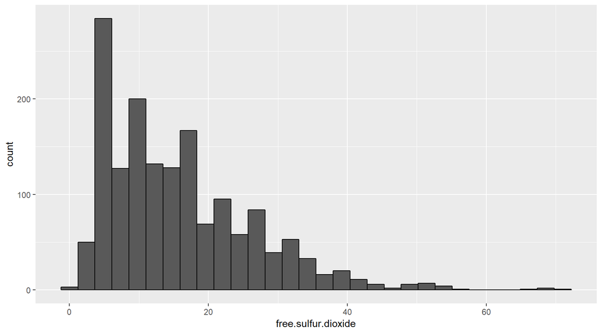

The distribution of free sulfur dioxide is right skewed.

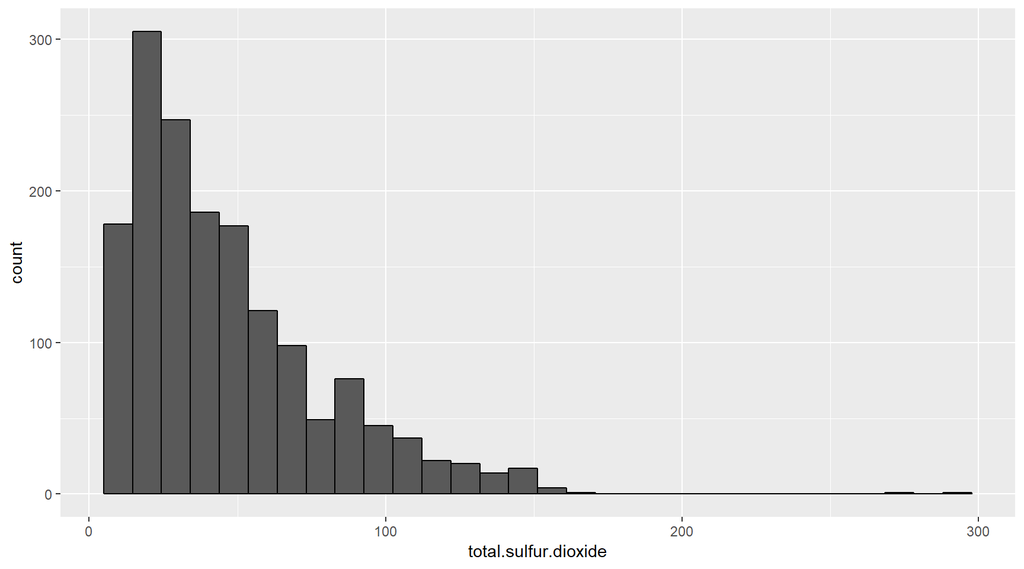

The distribution of total sulfur dioxide is right skewed.

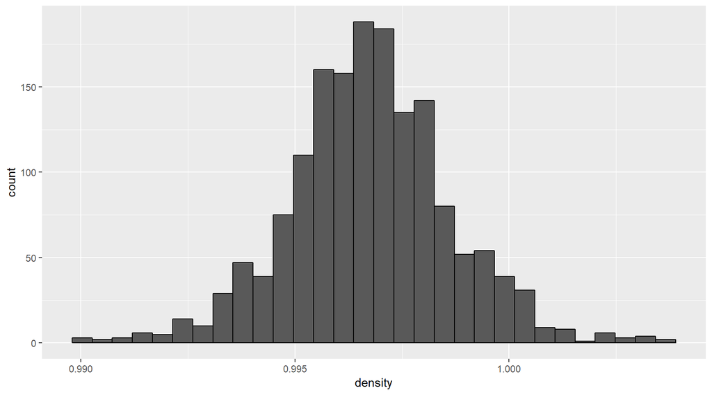

The distribution of density values are almost symmetric.

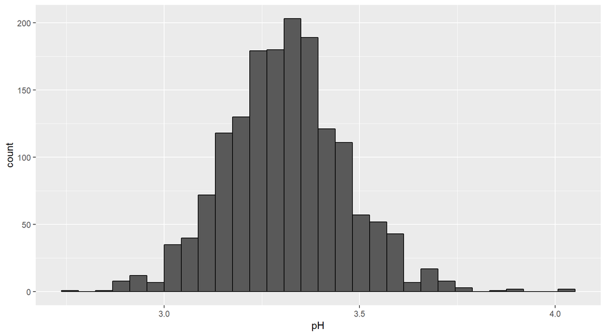

Most wines have a pH between 3.2 and 3.4. The distribution of pH is symmetrical.

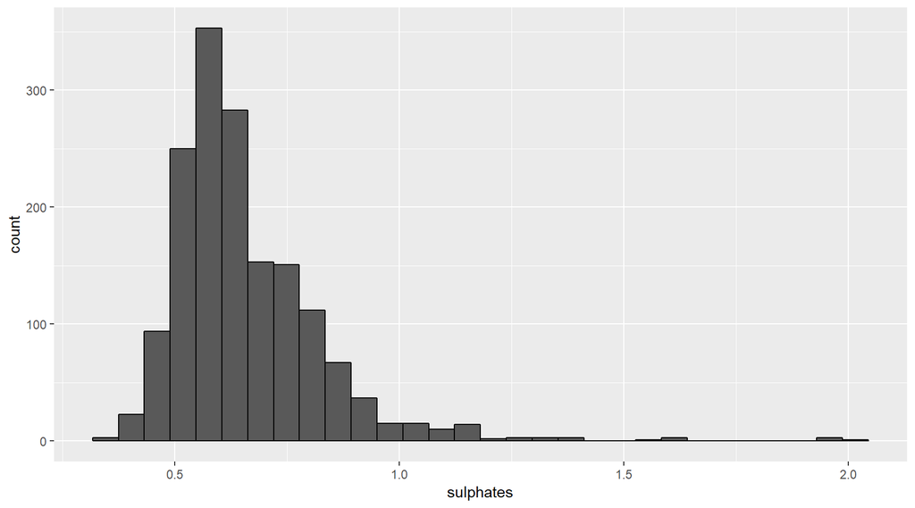

The distribution of total sulphates is right skewed.

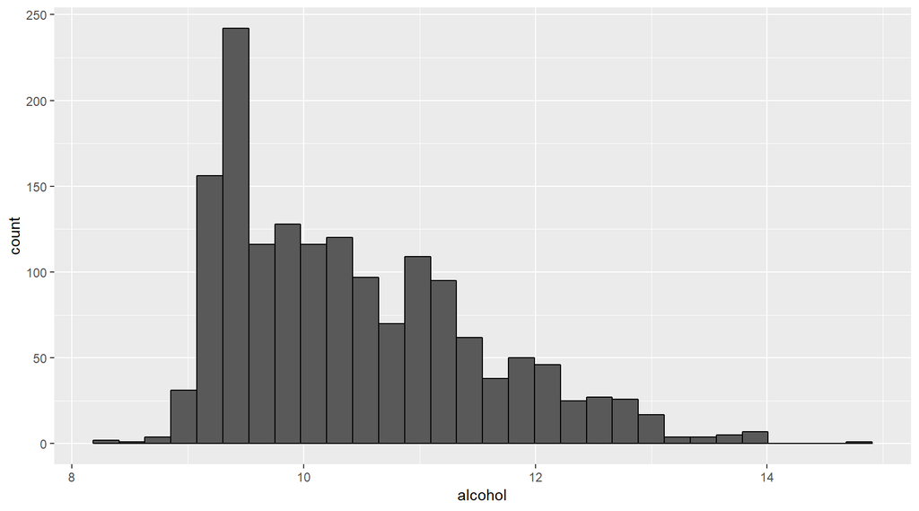

The distribution of alcohol value is positively skewed.

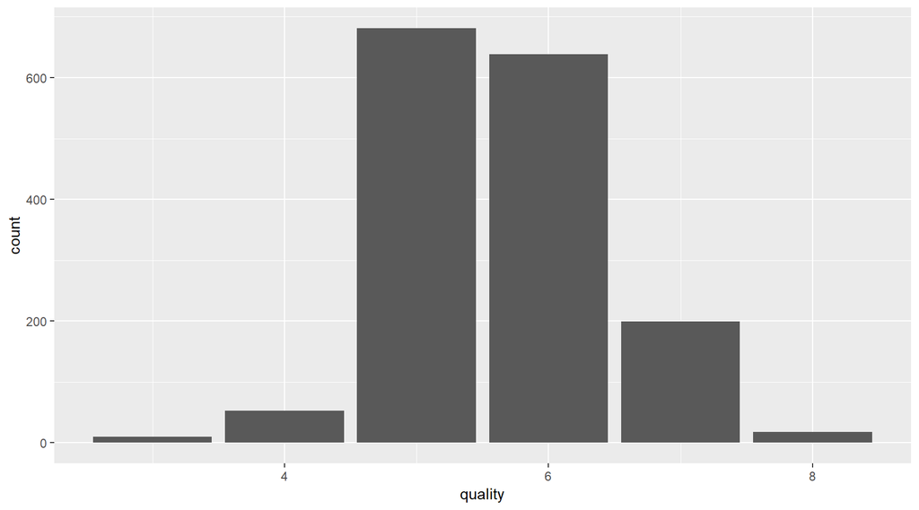

The possible quality score between 0 (very bad) and 10 (very excellent), but all of the red wines quality scores between 3 and 8.

# Univariate Analysis

### What is the structure of your dataset?

There are 1599 entries with 13 variables, one of them a categorical variable it added as quality rating and 11 variables based on physicochemical tests.

### What is/are the main feature(s) of interest in your dataset?

The main feature of interest is the quality rating.

### What other features in the dataset do you think will help support your investigation into your feature(s) of interest?

I think all the physicochemical test results of the11 features may help support to quality rating.

### Did you create any new variables from existing variables in the dataset?

NO.

### Of the features you investigated, were there any unusual distributions? Did you perform any operations on the data to tidy, adjust, or change the form of the data? If so, why did you do this?

There were no unusual distributions. I didn’t perfomr any cleaning process or change the form.

# Bivariate Plots Section

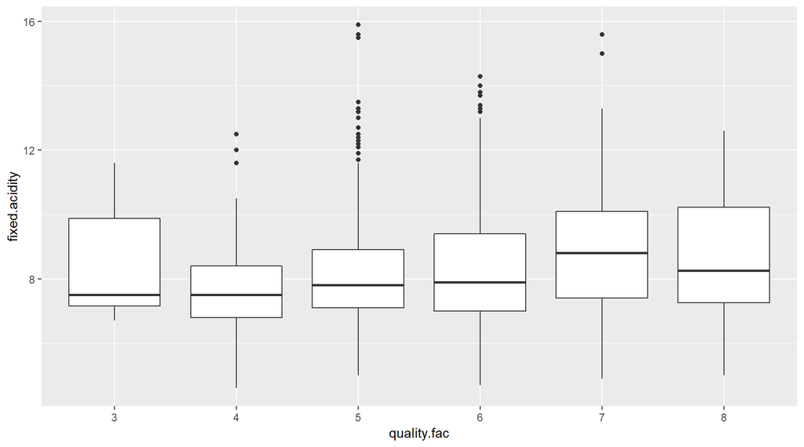

where it is shown that not have trend between them.

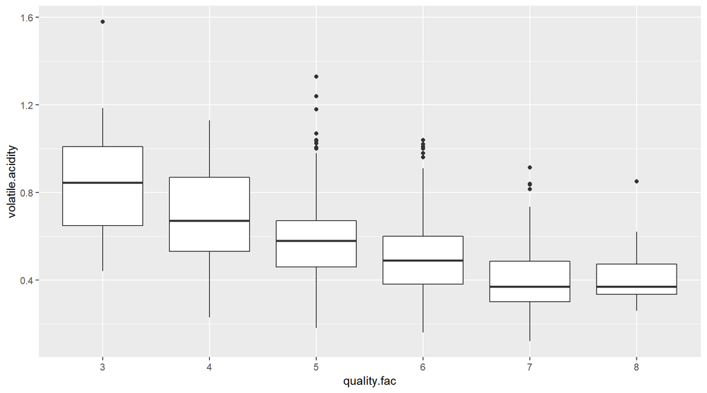

The more the volatile acidity, We have the lower the quality.

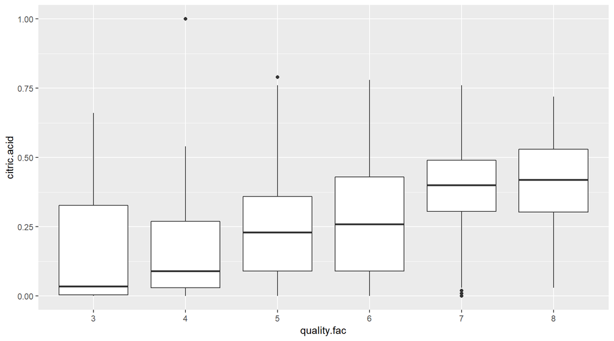

The more the citric acid, We have the higher the quality.

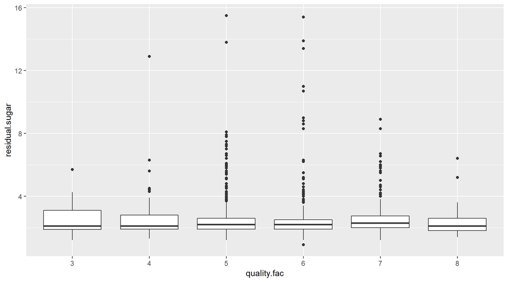

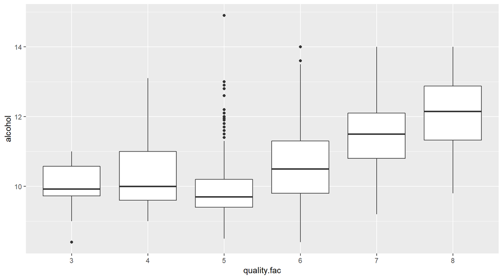

As alcohol increases, wine quality increases too.

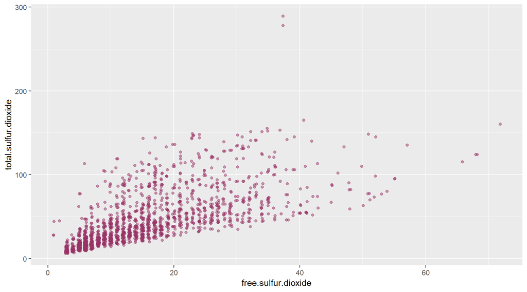

```
##
##  Pearson's product-moment correlation
##
## data:  Wine$free.sulfur.dioxide and as.numeric(Wine$total.sulfur.dioxide)
## t = 35.84, df = 1597, p-value < 2.2e-16
## alternative hypothesis: true correlation is not equal to 0
## 95 percent confidence interval:
##  0.6395786 0.6939740
## sample estimates:
##       cor
## 0.6676665
```

This can be the free sulfur dioxide and total sulfur dioxide have near points, correlation coefficient of 0.6676665 are positive relationship.

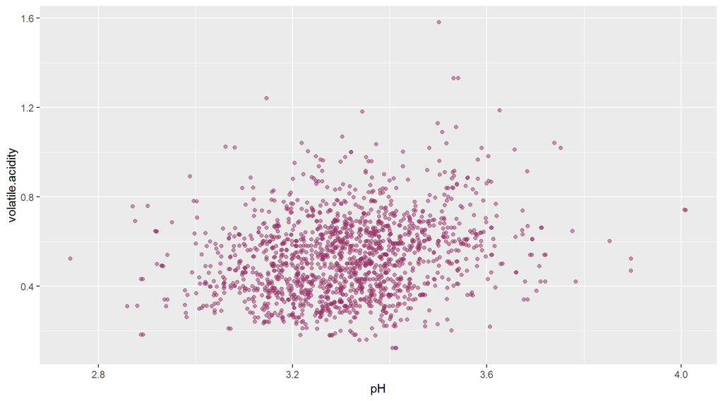

```
##
##  Pearson's product-moment correlation
##
## data:  Wine$pH and as.numeric(Wine$volatile.acidity)
## t = 9.659, df = 1597, p-value < 2.2e-16
## alternative hypothesis: true correlation is not equal to 0
## 95 percent confidence interval:
##  0.1880823 0.2807254
## sample estimates:
##       cor
## 0.2349373
```

The correlation coefficient of 0.2349373 a weak positive relationship between pH and volatile acidity.

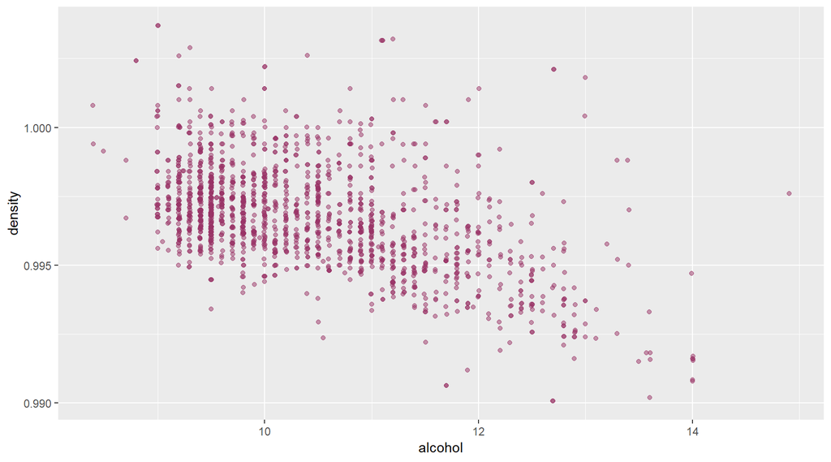

```
##
##  Pearson's product-moment correlation
##
## data:  Wine$alcohol and as.numeric(Wine$density)
## t = -22.838, df = 1597, p-value < 2.2e-16
## alternative hypothesis: true correlation is not equal to 0
## 95 percent confidence interval:
##  -0.5322547 -0.4583061
## sample estimates:
##        cor
## -0.4961798
```

The correlation coefficient of -0.4961798 a negative relationship between alcohol and density.

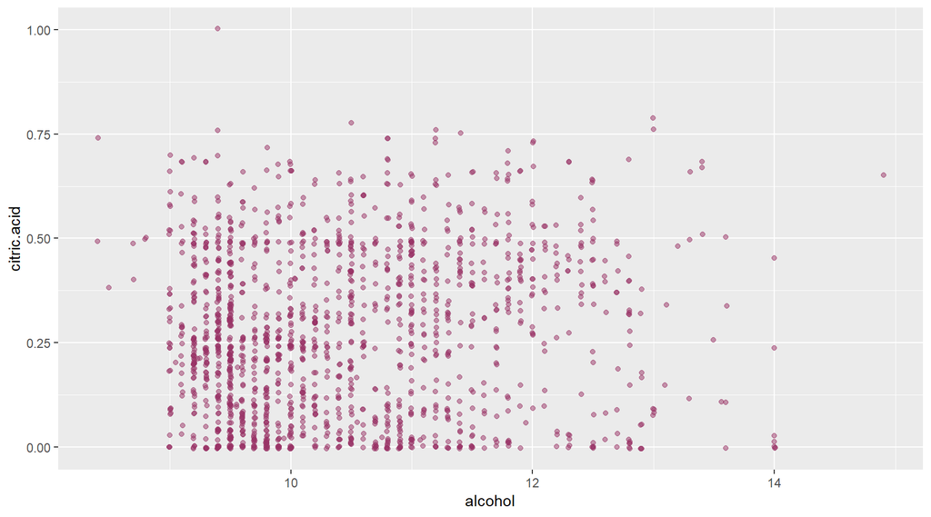

```
##
##  Pearson's product-moment correlation
##
## data:  Wine$alcohol and as.numeric(Wine$citric.acid)
## t = 4.4188, df = 1597, p-value = 1.059e-05
## alternative hypothesis: true correlation is not equal to 0
## 95 percent confidence interval:
##  0.06121189 0.15807276
## sample estimates:
##       cor
## 0.1099032
```

The correlation coefficient of 0.1099032 a weak positive relationship between alcohol and citric acid.

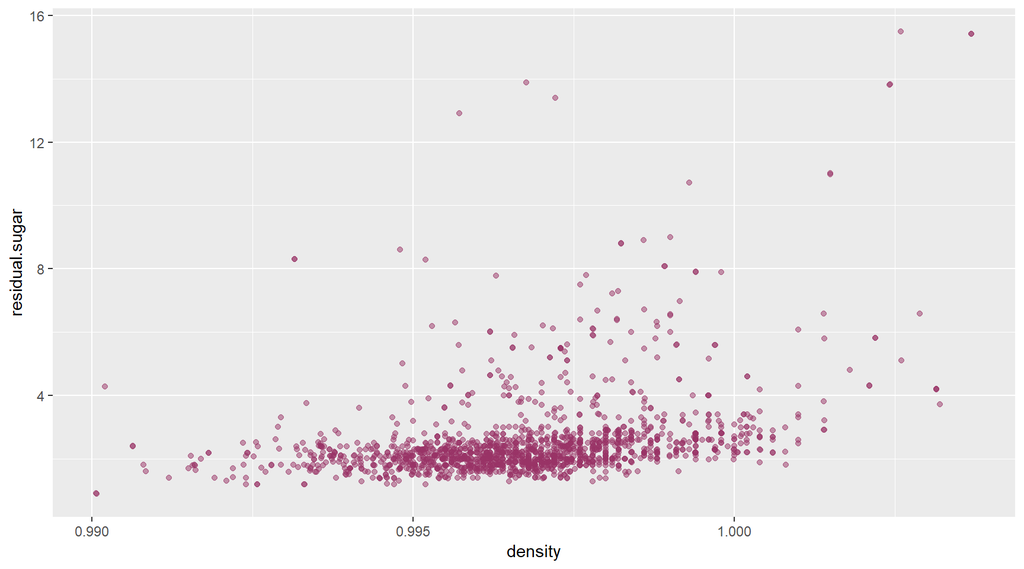

```
##
##  Pearson's product-moment correlation
##
## data:  Wine$density and as.numeric(Wine$residual.sugar)
## t = 15.189, df = 1597, p-value < 2.2e-16
## alternative hypothesis: true correlation is not equal to 0
## 95 percent confidence interval:
##  0.3116908 0.3973835
## sample estimates:
##       cor
## 0.3552834
```

The correlation coefficient of 0.3552834 a positive relationship between density and residual sugar.

# Bivariate Analysis

### Did you observe any interesting relationships between the other features (not the main feature(s) of interest)?

Yes, pH vs volatile.acidity.

# Multivariate Plots Section

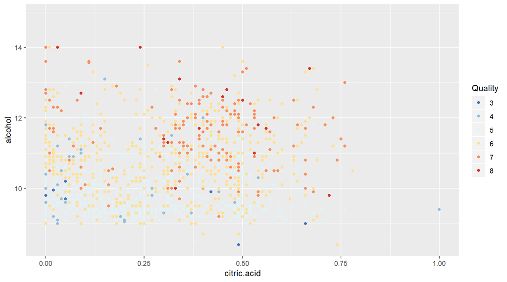

The quality wines high with high citric acid and high alcohol.

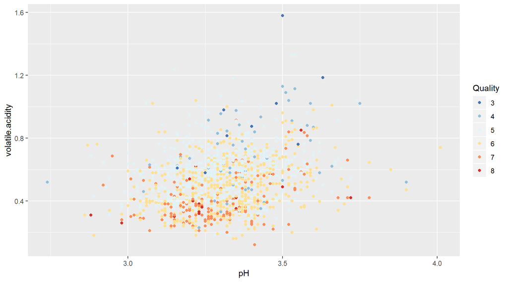

High quality wines tend to have low volatile acidity and low pH (lower left corner).

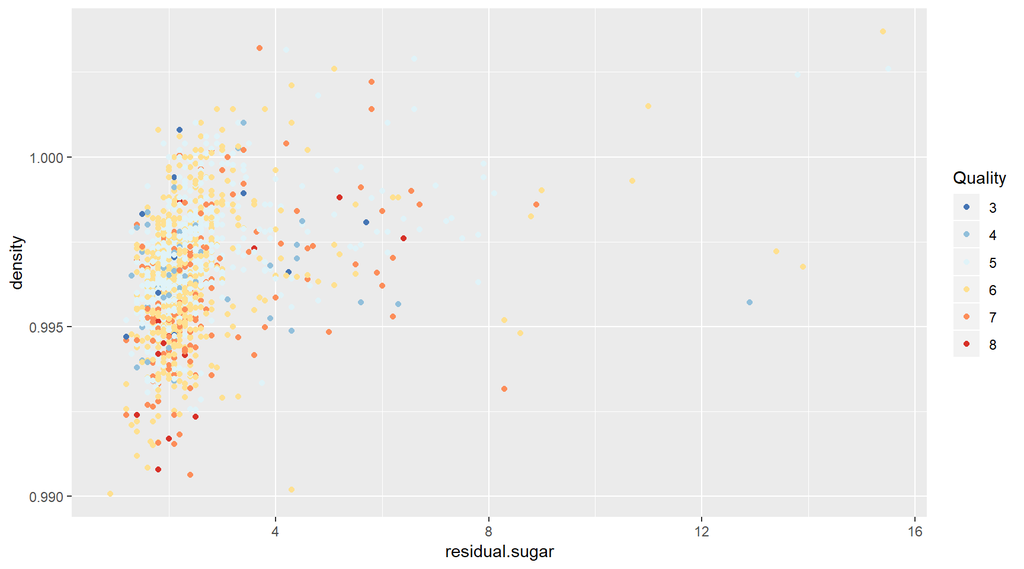

High quality wines tend to have low residual sugar and low density (lower left corner).

# Multivariate Analysis

### Talk about some of the relationships you observed in this part of the investigation. Were there features that strengthened each other in terms of looking at your feature(s) of interest?

In the previous section we have positive relationship between Volatile Acidity and pH, in this section we see negative relationship in Volatile Acidity and pH vs Quality.

### Were there any interesting or surprising interactions between features?

Citric Acid and Alcohol vs Quality, the quality wines high with high them clearly.

### OPTIONAL: Did you create any models with your dataset? Discuss the strengths and limitations of your model.

NO

# Final Plots and Summary

### Plot One

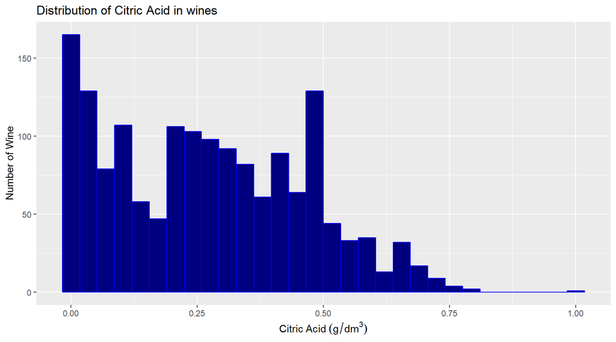

```
##    Min. 1st Qu.  Median    Mean 3rd Qu.    Max.
##   0.000   0.090   0.260   0.271   0.420   1.000
```

### Plot Two

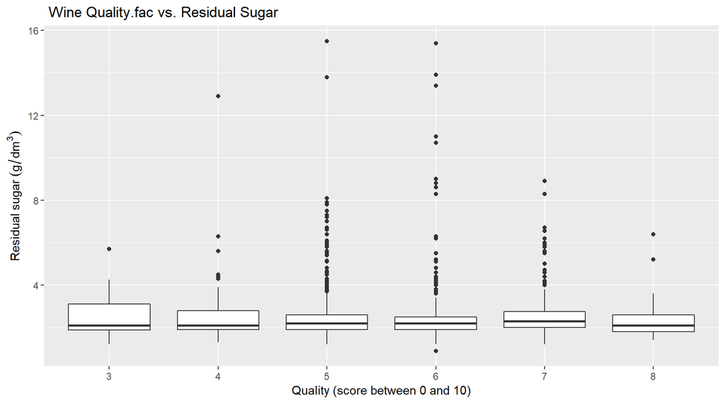

```
##    Min. 1st Qu.  Median    Mean 3rd Qu.    Max.
##   0.900   1.900   2.200   2.539   2.600  15.500
```

### Plot Three

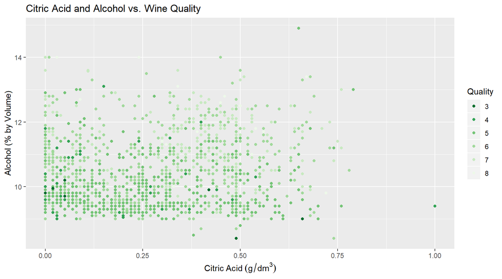

# Reflection

I started by exploring each variable individually plot then created 2 variable plot then 3 variables plot.

Finally, in future work could be build a use classification models to classifier the wine quality based on the chemical attributes. We could improve the quality of our analysis by collecting more data and more information about the composition of wine to informs the commentary like how the components of wine affect the taste of wine.